# Modèles de survie paramétriques

Ceci est un “notebook”. Il permet d’écrire du code au milieu du texte et d’afficher son résultat lorsque le document est compilé. Vous pouvez également utiliser les icones en haut à droite de chaque “chunk” (partie où se trouve le code), par exemple, la flèche verte permet de ne recompiler que cette partie.

Ce document est écrit en language markdown. Les bases qui vous permettront de comprendre la sytaxe sont juste que le “#” permet de définir le niveau du titre (“#” = titre 1; “##” = titre 1.1; “###” = titre 1.1.1;…). Le code R est écrit entre 2 balises, une d’ouverture du chunk et une de fermeture. Exemple:

```r
head(cars)
```

```
##   speed dist
## 1     4    2
## 2     4   10
## 3     7    4
## 4     7   22
## 5     8   16
## 6     9   10
```

Le résultat du code s’affiche en dessous si vous compilez le document, ou juste ce chunck en cliquant sur la flèche verte.

Finalement, lorsque votre document est terminé, vous pouvez obtenir une version clean en cliquant sur le bouton “preview” ou en tapant *Ctrl+Shift+K*. Un fichier de type html se trouve maintenant à côté de votre fichier Rmd, que vous pouvez garder pour vous ou envoyer à quelqu’un, il suffit d’un navigateur internet (même sans connexion) pour pouvoir l’afficher.

**! Note : !** en cas de symbole étrange dans les phrases du notebook, cela indique un problème d’encodage. Pour résoudre le problème `Tools > Global Options > Code > Saving ; Choisir iso-8859-1 ; Fermer et rouvrez votre RStudio`. Si vous souhaitez plus tard le compilez en pdf ou en HTML il faudra l’enregistrer en UFT-8 `File > Save with Encoding ... > UTF-8`

Revenons maintenant au cours…

# 1 Pourquoi utiliser un modèle paramétrique ?

L’utilisation de modèles non-paramétrique ou semi-paramétrique (ex : Cox) présentent de nombreux avantages, mais également de nombreuses limites du fait de l’absence d’une forme structurée. En effet, le risque de base estimé par ces modèles est très fidèles aux données, mais trop pour pouvoir extrapoler à de nouvelles données.

Mais à quoi cela ressemble-t-il ?  
Prenons exemple de la distribution de Weibull :

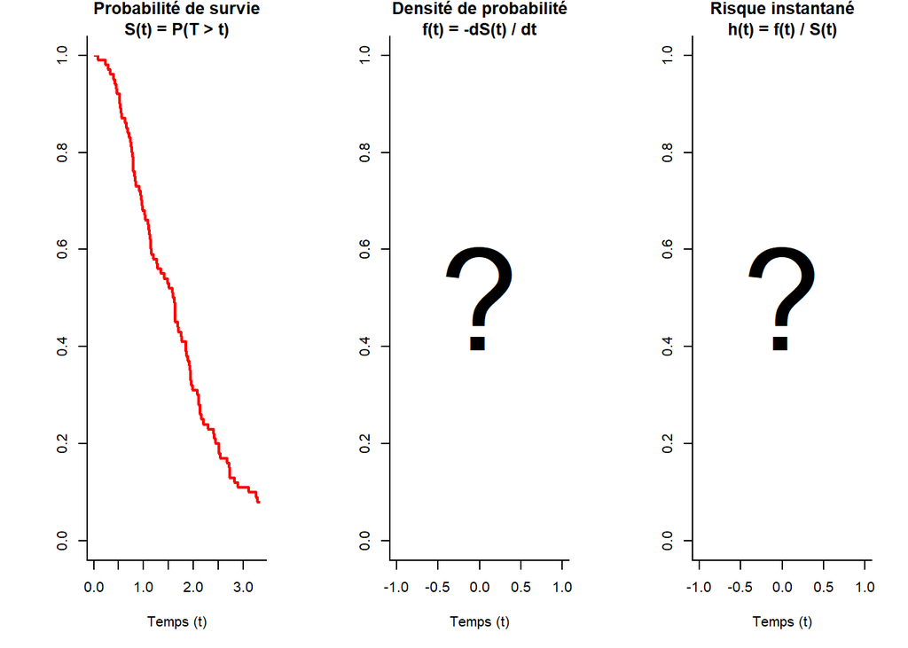

```r
library(survival)
pts <- 0:100/30
sc <- 2
sh <- 1.5
XLAB = 'Temps (t)'
N <- 100
set.seed(1)
times <- rweibull(N, sh, sc)
event <- rep(1, N)
par(mfrow=c(1, 3), mar = c(5, 5, 2, 2) + .1, bty='l')
plot(survfit(Surv(times, event) ~ 1), ylim=0:1,main = 'Probabilité de survie\nS(t) = P(T > t)',ylab = '',xlab = XLAB, lwd=2, col='red', xmax = max(pts), conf.int = FALSE)
plot(0,0, ty='l',ylim=0:1,main = 'Densité de probabilité\nf(t) = -dS(t) / dt',ylab = '', xlab = XLAB, lwd=2, col='white')
text(0,0.5,"?",cex=10)
plot(0,0, ty='l',ylim=0:1,main = 'Risque instantané\nh(t) = f(t) / S(t)',ylab = '', xlab = XLAB, lwd=2, col='white')
text(0,0.5,"?",cex=10)
```

Sur le premier plot de la figure, à chaque temps t, la pente de cette fonction est égale à 0 lorsqu’il n’y a pas d’évènement et à $\infty$ lorsqu’il y a un évènement.  
Lorsque l’on dérive cette distribution de survie, on a une nouvelle distribution (2nd graphique) où chaque trait vertical correspond à une densité allant vers $\infty$ (car 1/0=$\infty$) :

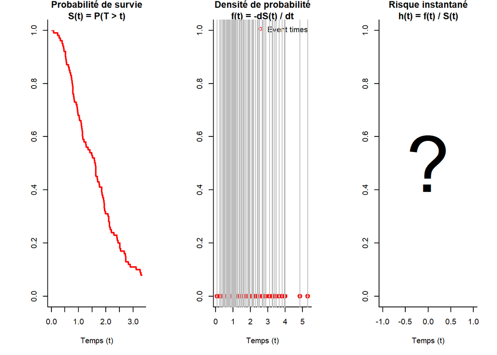

```r
par(mfrow=c(1, 3), mar = c(5, 5, 2, 2) + .1, bty='l')
plot(survfit(Surv(times, event) ~ 1), ylim=0:1,main = 'Probabilité de survie\nS(t) = P(T > t)',ylab = '',xlab = XLAB, lwd=2, col='red', xmax = max(pts), conf.int = FALSE)
plot(times[event==1],rep(0,sum(event)),ylim=0:1,main = 'Densité de probabilité\nf(t) = -dS(t) / dt',ylab = '', xlab = XLAB, lwd=2, col='red')
legend("topright","Event times",pch=1,col='red',bty="n")
abline(v=times[event==1],col="grey")
plot(0,0, ty='l',ylim=0:1,main = 'Risque instantané\nh(t) = f(t) / S(t)',ylab = '', xlab = XLAB, lwd=2, col='white')
text(0,0.5,"?",cex=10)
```

La fonction de risque instanané est donc défini également de la sorte :

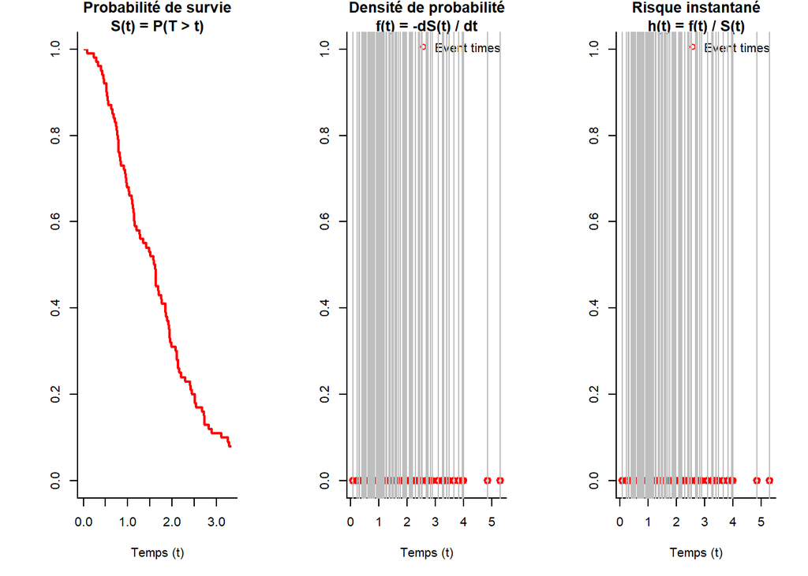

```r
par(mfrow=c(1, 3), mar = c(5, 5, 2, 2) + .1, bty='l')
plot(survfit(Surv(times, event) ~ 1), ylim=0:1,main = 'Probabilité de survie\nS(t) = P(T > t)',ylab = '',xlab = XLAB, lwd=2, col='red', xmax = max(pts), conf.int = FALSE)
plot(times[event==1],rep(0,sum(event)),ylim=0:1,main = 'Densité de probabilité\nf(t) = -dS(t) / dt',ylab = '', xlab = XLAB, lwd=2, col='red')
legend("topright","Event times",pch=1,col='red',bty="n")
abline(v=times[event==1],col="grey")
plot(times[event==1],rep(0,sum(event)),ylim=0:1,main = 'Risque instantané\nh(t) = f(t) / S(t)',ylab = '', xlab = XLAB, lwd=2, col='red')
legend("topright","Event times",pch=1,col='red',bty="n")
abline(v=times[event==1],col="grey")
```

**Dans un autre contexte**, prenons les poids de souris mesurés lors d’une expérience. Nous connaissons leur distribution, elle suit une loi normale.  
Utiliser une méthode non-paramétrique similaire reviendrait à avoir une distribution telle que celle-ci :

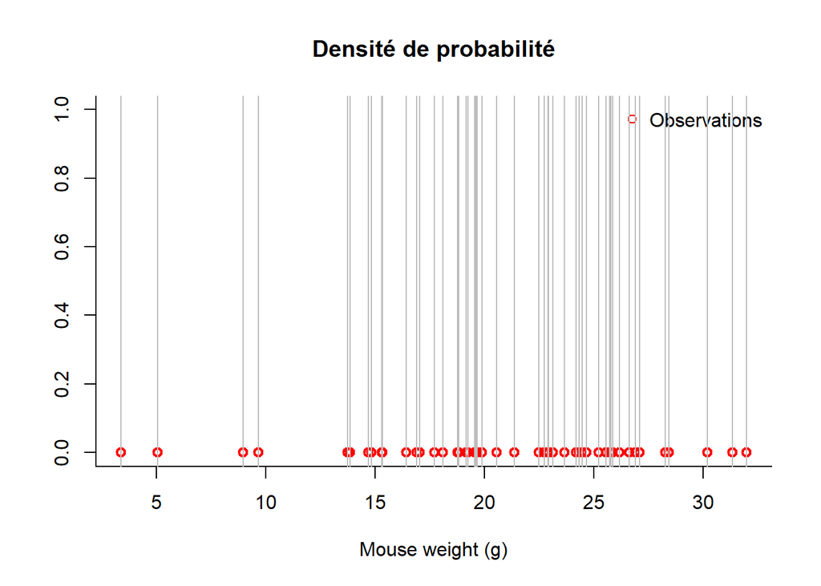

```r
N <- 50
set.seed(1)
x <- rnorm(N,20,7.5)
plot(x,rep(0,length(x)),ylim=0:1,main = 'Densité de probabilité',ylab = '', xlab = "Mouse weight (g)", lwd=2, col='red',bty='l')
legend("topright","Observations",pch=1,col='red',bty="n")
abline(v=x,col="grey")
```

Il est impossible de faire des prédictions de nouvelles observations à partir de cette distribution. De ce fait, il est courant de placer une densité de probabilité sur ces points, représentant leur densité/concentration (forme que l’on connait) :

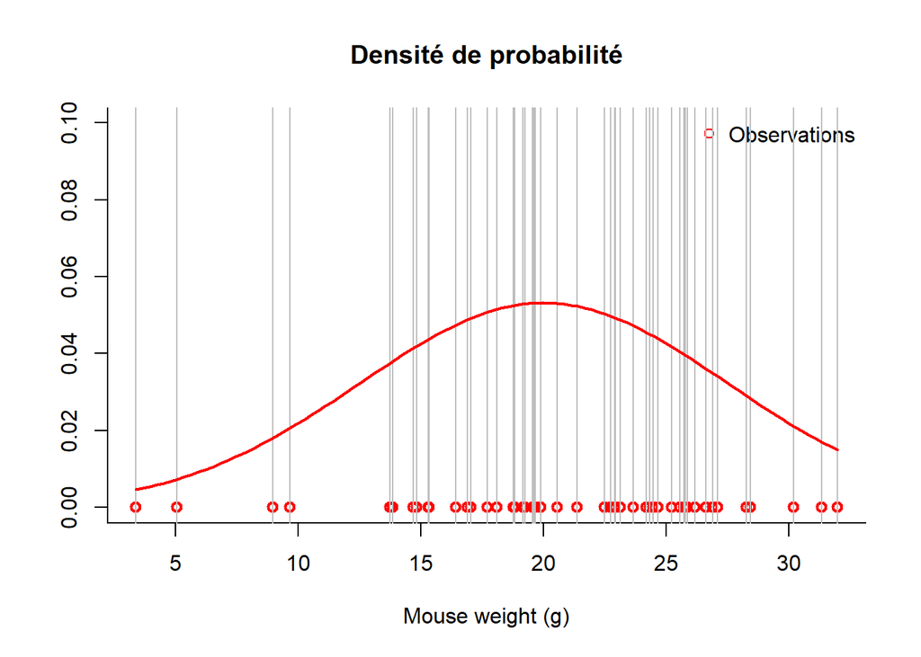

```r
plot(x,rep(0,length(x)),ylim=c(0,0.1),main = 'Densité de probabilité',ylab = '', xlab = "Mouse weight (g)", lwd=2, col='red',bty='l')
legend("topright","Observations",pch=1,col='red',bty="n")
abline(v=x,col="grey")
curve(dnorm(x,20,7.5),add=T,lwd=2,col='red')
```

Ici, on place un modèle gaussien sur les poids des souris. **A partir de ce modèle, nous pouvons** :

- calculer facilement des statistiques correspondantes à ces distributions (moyenne, médiane,…) grâce aux formules analytiques
- faire de la prédiction de temps de survie
- extrapoler les résultats en dehors des limites de l’échantillon (au delà du dernier temps observé)
- réaliser des études de simulations en tirant au hasard des valeurs dans cette distribution pour créer une population “synthétique” (souvent utilisée pour, entre autre, faire du calcul de taille d’échantillon, tester les performances d’un modèle et/ou sa robustesse aux écart à ses hypothèses,…)

Cela permet également de restreindre le modèle pour limiter le sur-apprentissage, i.e. permettre d’avoir un modèle qui pourra extrapoler au delà de sa population d’apprentissage (cf cours modèles prédictifs).

**Pour revenir à la survie**, nous aurons une fonction de survie plus lisse qu’un estimateur non-paramétrique et nous pouvons définir la densité de probabilité et la fonction de risque instantané :

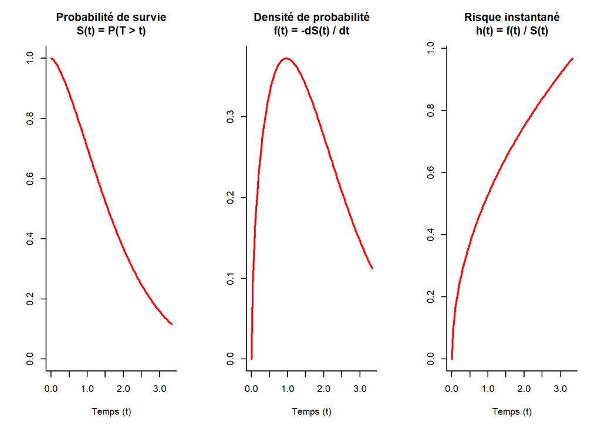

```r
pts <- 0:100/30
sc <- 2
sh <- 1.5
XLAB = 'Temps (t)'
#par(xaxs='i', mfrow=c(1, 3), bty='l')
par( mfrow=c(1, 3), bty='l')
plot(pts, pweibull(pts, sh, sc, lower.tail = FALSE), ty='l', ylim=0:1,main = 'Probabilité de survie\nS(t) = P(T > t)',ylab = '', xlab = XLAB, lwd=2, col='red')
plot(pts, dweibull(pts, sh, sc), ty='l',main = 'Densité de probabilité\nf(t) = -dS(t) / dt',ylab = '', xlab = XLAB, lwd=2, col='red')
plot(pts, dweibull(pts, sh, sc) / pweibull(pts, sh, sc, lower.tail = FALSE),ty='l', main = 'Risque instantané\nh(t) = f(t) / S(t)',ylab = '', xlab = XLAB, lwd=2, col='red')
```

# 2 Dataset

Pour cette partie du TP, nous utiliserons le data “kidney” disponible dans le package survival.

```r
library('survival')
data('kidney')
head(kidney)
```

```
##   id time status age sex disease frail
## 1  1    8      1  28   1   Other   2.3
## 2  1   16      1  28   1   Other   2.3
## 3  2   23      1  48   2      GN   1.9
## 4  2   13      0  48   2      GN   1.9
## 5  3   22      1  32   1   Other   1.2
## 6  3   28      1  32   1   Other   1.2
```

La variable `sex` sera considérée comme variable explicative lors de ce TP. C’est une variable binaire, codé par “1” et “2”, et non par “0” et “1”, il faudra donc être vigilent sur l’écriture du programme pour ne pas considérer cette valeur comme une variable continue. Recodons la tout de suite pour éviter la confusion :

```r
kidney$sex=kidney$sex-1
```

# 3 Distributions de survie paramétriques

## 3.1 Récapitulatif

Dans ce TP, nous utiliserons les paraméterisations du package survival qui correspondent également à celle que vous pourrez rtetrouver dans certains documents, y compris les pages wikipedia de ces distributions. Afin de ne pas vous perdre, le tableau ci-dessous fait compare les fonctions de survie associées par rapport à celles que vous avez pu voir en cours.

| Famille | Package survival | Cours |
| --- | --- | --- |
| Exponentielle | $\exp(- \lambda t)$ | $\exp(- \lambda t)$ |
| Weibull | $\exp(- (\frac{t}{\lambda})^{\frac{1}{\sigma}})$ | $\exp(-(\lambda t)^\frac{1}{\sigma})$ |
| Log-normal | $1 - \Phi\left(\frac{\ln(t)-\mu}\sigma \right)$ | - |
| Log-logistique | $\frac{1}{1+\exp(\frac{\ln(t) - \mu)}{\sigma})}$ | $\frac{1}{1+(\lambda t)^{\gamma}}$ |

Là où les paramètres de forme (shape, $\sigma$) vont quantifier la dispersion de la distribution, les paramètres d’échelle (scale, $\lambda$ et $\mu$) vont être ceux correspondant au mode de la distribution, et donc être les plus pertinents pour caractériser la survie (c’est sur ce paramètre que seront posés les coefficients de régression, cf ci-dessous).

**Pour les modèles de regression**, le(s) paramètre(s) $\lambda$ et $\mu$ résultent de l’exponentielle d’une combinaison linéaires des variables, c’est-à-dire : $\lambda=\exp(-(\beta_0+\beta_1 X1 +\beta_2 X2 +...+\beta_p Xp))$. Ce sont les coefficients de regression $\beta$ qui sont fournis par la sortie des fonctions de R. **Leur interprétation** dépend donc de leur signe, mais également de la forme de la fonction de survie et est détaillée dans les paragraphes ci-dessous.

## 3.2 Estimation des paramètres

Dans cette section, les codes de base pour utiliser les différentes régression sont présentées, ainsi que l’interprétations de leurs sorties. *Pour résumer l’interprétation des coefficients*, un coefficient associé à une variable explicative $>0$ implique une augmentation de la probabilité de survie à chaque temps $t$, et réciproquement.

### 3.2.1 Modèle exponentiel

#### 3.2.1.1 Distribution exponentielle

Dans le cadre du modèle exponentiel, on a $S(t)=\exp(- \lambda t)$. Plus $\lambda$ augmente, plus la survie attendue est faible. Même si les formules analytiques existent, nous pouvons aussi calculer son paramètre avec la fonction `survreg` du package `survival` de la façon suivante :

```r
fit_exp<-survreg(Surv(time,status) ~ 1, kidney,dist="exponential")
summary(fit_exp)
```

```
##
## Call:
## survreg(formula = Surv(time, status) ~ 1, data = kidney, dist = "exponential")
##             Value Std. Error    z      p
## (Intercept) 4.892      0.131 37.2 <2e-16
##
## Scale fixed at 1
##
## Exponential distribution
## Loglik(model)= -341.7   Loglik(intercept only)= -341.7
## Number of Newton-Raphson Iterations: 5
## n= 76
```

```r
(beta0_exp<-fit_exp$coef) #extraction de la valeur de beta0
```

```
## (Intercept)
##    4.891645
```

```r
(lambda_exp<-exp(-beta0_exp))
```

```
## (Intercept)
## 0.007509063
```

#### 3.2.1.2 Régression exponentielle

La régression exponentielle multivariable considère $\lambda = \exp(-(\beta_0 + \beta_1 * X_1 + \beta_2 * X_2+ ...+X_p))$, correspondant à la fonction de survie $S(t) =\exp(- e^{-(\beta_0 + \beta_1 * X_1 + \beta_2 * X_2+ ...+X_p)} t)$. En reprenant l’exemple précédent, ajustons le modèle pour la variable `sex` :

```r
fit_exp2<-survreg(Surv(time,status) ~ sex, kidney,dist="exponential")
summary(fit_exp)
```

```
##
## Call:
## survreg(formula = Surv(time, status) ~ 1, data = kidney, dist = "exponential")
##             Value Std. Error    z      p
## (Intercept) 4.892      0.131 37.2 <2e-16
##
## Scale fixed at 1
##
## Exponential distribution
## Loglik(model)= -341.7   Loglik(intercept only)= -341.7
## Number of Newton-Raphson Iterations: 5
## n= 76
```

```r
betas_exp<-fit_exp2$coef #extraction de la valeur des betas
exp(-exp(-betas_exp[1])) #Survie chez les hommes
```

```
## (Intercept)
##   0.9849375
```

```r
exp(-exp(-sum(betas_exp))) #survie chez les femmes
```

```
## [1] 0.9939006
```

### 3.2.2 Modèle de Weibull

#### 3.2.2.1 Distribution de Weibull

```r
fit_weib<-survreg(Surv(time,status) ~ 1, kidney,dist="weibull")
summary(fit_weib)
```

```
##
## Call:
## survreg(formula = Surv(time, status) ~ 1, data = kidney, dist = "weibull")
##              Value Std. Error     z      p
## (Intercept) 4.8523     0.1506 32.22 <2e-16
## Log(scale)  0.1181     0.0975  1.21   0.23
##
## Scale= 1.13
##
## Weibull distribution
## Loglik(model)= -340.9   Loglik(intercept only)= -340.9
## Number of Newton-Raphson Iterations: 6
## n= 76
```

L’intercept correspond comme précédemment à celui de la régression sur $\lambda$, c’est-à-dire, $\lambda=exp(\beta_0)$, correspondant à la fonction de survie $S(t)=\exp(- (\frac{t}{exp(\beta_0)})^{\frac{1}{\sigma}})$. Plus $\beta_0$ augmente, plus $\lambda$ augmente, plus la survie attendue est élevée. Pourquoi cette relation (augmentation de $\beta_0$ $=$ augmentation de la survie) est similaire au modèle exponentiel malgrès l’absence de “-” dans l’exponentielle ? Ceci est due à une des propriété de base de la fonction exponentielle : $\frac{1}{\exp(x)}=\exp(-x)$. Pour simplifier, si $\sigma=1$, on a $\frac{1}{\lambda_{Weibull}}=\frac{1}{\beta0}=\exp(-\beta0)=\lambda_{exponentiel}$. Nous pouvons retrouver notre $\lambda$ (et notre $\sigma$) à partir de l’objet `survfit` par :

```r
beta0_weib<-fit_weib$coef #extraction de la valeur de beta0
(lambda_weib<-exp(beta0_weib))
```

```
## (Intercept)
##    128.0324
```

```r
(scale_weib<-fit_weib$scale)
```

```
## [1] 1.125386
```

#### 3.2.2.2 Régression de Weibull

De façon similaire à la régression de Weibull multivariable considère $\lambda = \exp(-(\beta_0 + \beta_1 * X_1 + \beta_2 * X_2+ ...+X_p))$. En reprenant l’exemple précédent, ajustons le modèle pour la variable `sex` :

```r
fit_weib2<-survreg(Surv(time,status) ~ sex, kidney,dist="weibull")
summary(fit_weib2)
```

```
##
## Call:
## survreg(formula = Surv(time, status) ~ sex, data = kidney, dist = "weibull")
##              Value Std. Error     z      p
## (Intercept) 4.0947     0.2734 14.98 <2e-16
## sex         0.9866     0.3219  3.07 0.0022
## Log(scale)  0.1008     0.0935  1.08 0.2810
##
## Scale= 1.11
##
## Weibull distribution
## Loglik(model)= -336.6   Loglik(intercept only)= -340.9
##  Chisq= 8.61 on 1 degrees of freedom, p= 0.0033
## Number of Newton-Raphson Iterations: 5
## n= 76
```

Ce modèle correspond à $\lambda = \exp(-(\beta_0 + \beta_1 * sex))$ et $S(t)=\exp(- (\frac{t}{exp(\beta_0+ \beta_1 * sex)})^{\frac{1}{\sigma}})$. Nous pouvons retrouver $\lambda$ et $\sigma$ facilement à partir de l’objet `survfit`:

```r
betas_weib<-fit_weib2$coef #extraction de la valeur des betas
lambda_weib2<-exp(betas_weib)
scale_weib2<-fit_weib2$scale
```

```r
betas_weib<-fit_weib2$coef #extraction de la valeur des betas
exp(-(1/betas_exp[1])^(1/scale_weib2)) #Survie chez les hommes
```

```
## (Intercept)
##   0.7603783
```

```r
exp(-(1/sum(betas_exp))^(1/scale_weib2)) #survie chez les femmes
```

```
## [1] 0.795023
```

### 3.2.3 Modèle log-normale

#### 3.2.3.1 Distribution log-normale

Dans le cadre du modèle de log-normale, la fonction `survreg` considère la paraméterisation $S(t) = 1 - \Phi\left(\frac{\ln(t)-\mu}\sigma \right)$. Plus $\mu$ augmente, plus la survie attendue sera élevée. Nous pouvons calculer ses paramètres avec la fonction `survreg` du package `survival` de la façon suivante :

```r
fit_logNorm<-survreg(Surv(time,status) ~ 1, kidney,dist="lognormal")
summary(fit_logNorm)
```

```
##
## Call:
## survreg(formula = Surv(time, status) ~ 1, data = kidney, dist = "lognormal")
##              Value Std. Error     z      p
## (Intercept) 4.2240     0.1656 25.51 <2e-16
## Log(scale)  0.2854     0.0913  3.12 0.0018
##
## Scale= 1.33
##
## Log Normal distribution
## Loglik(model)= -340   Loglik(intercept only)= -340
## Number of Newton-Raphson Iterations: 6
## n= 76
```

L’intercept correspond comme précédemment à celui de la régression sur $\mu$, c’est-à-dire, $\mu=\beta_0$, correspondant à la fonction de survie $S(t) = 1 - \Phi\left(\frac{\ln(t)-\beta_0}\sigma \right)$. The `log(scale)` correspond à $\sigma$. Plus $\beta_0$ augmente, plus $\mu$ augmente, plus la survie attendue est élevée. Nous pouvons retrouver notre $\mu$ (et notre $\sigma$) à partir de l’objet `survfit` par :

```r
mu_logNorm<-fit_logNorm$coef
scale_logNorm<-fit_logNorm$scale
```

#### 3.2.3.2 Régression log-normale

La régression log-normale multivariable considère $\mu = \beta_0 + \beta_1 * X_1 + \beta_2 * X_2+ ...+X_p$. En reprenant l’exemple précédent, ajustons le modèle pour la variable `sex` :

```r
fit_logNorm2<-survreg(Surv(time,status) ~ sex, kidney,dist="lognormal")
summary(fit_logNorm2)
```

```
##
## Call:
## survreg(formula = Surv(time, status) ~ sex, data = kidney, dist = "lognormal")
##              Value Std. Error     z       p
## (Intercept) 3.2211     0.2756 11.69 < 2e-16
## sex         1.3682     0.3270  4.18 2.9e-05
## Log(scale)  0.1726     0.0909  1.90   0.058
##
## Scale= 1.19
##
## Log Normal distribution
## Loglik(model)= -332.1   Loglik(intercept only)= -340
##  Chisq= 15.84 on 1 degrees of freedom, p= 6.9e-05
## Number of Newton-Raphson Iterations: 4
## n= 76
```

Nous pouvons extraire facilement ces paramètres depuis l’objet `survfit` :

```r
mu_logNorm2<-fit_logNorm2$coef
scale_logNorm2<-fit_logNorm2$scale
```

Ce modèle correspond à $\mu = \beta_0 + \beta_1 * sex$ et $S(t) = 1 - \Phi\left(\frac{\ln(t)-(\beta_0 + \beta_1 * sex)}\sigma \right)$. Comme précédemment, plus $\beta_0+ \beta_1 * sex$ augmente, plus $\mu$ augmente, plus la survie attendue est élevée. Comme $\beta_1=1.37$, $\beta_0+ \beta_1 * sex$ est plus élevé chez les femmes, la survie attendue chez les femmes est donc plus élevée que chez les hommes. Vérifions cela d’après les formules précédentes :

```r
1-pnorm((log(1)-mu_logNorm2[1])/scale_logNorm2) #Survie chez les hommes
```

```
## (Intercept)
##   0.9966414
```

```r
1-pnorm((log(1)-sum(mu_logNorm2))/scale_logNorm2) #survie chez les femmes
```

```
## [1] 0.9999437
```

### 3.2.4 Modèle log-logistique

#### 3.2.4.1 Distribution log-logistique

Dans le cadre du modèle de log-logistique, la fonction `survreg` considère la paraméterisation $S(t) = \frac{1}{1+\exp(\frac{\ln(t) - \mu)}{\sigma})}$. Plus $\mu$ augmente, plus la survie attendue sera élevée. Nous pouvons calculer ses paramètres avec la fonction `survreg` du package `survival` de la façon suivante :

```r
fit_logLogi<-survreg(Surv(time,status) ~ 1, kidney,dist="loglogistic")
summary(fit_logLogi)
```

```
##
## Call:
## survreg(formula = Surv(time, status) ~ 1, data = kidney, dist = "loglogistic")
##              Value Std. Error     z      p
## (Intercept)  4.250      0.175 24.30 <2e-16
## Log(scale)  -0.229      0.104 -2.21  0.027
##
## Scale= 0.795
##
## Log logistic distribution
## Loglik(model)= -342   Loglik(intercept only)= -342
## Number of Newton-Raphson Iterations: 5
## n= 76
```

L’intercept correspond comme précédemment à celui de la régression sur $\mu$, c’est-à-dire, $\mu=\beta_0$, correspondant à la fonction de survie $S(t) = \frac{1}{1+\exp(\frac{\ln(t) - \beta_0)}{\sigma})}$. The `log(scale)` correspond à $\sigma$. Plus $\beta_0$ augmente, plus $\mu$ augmente, plus la survie attendue est élevée. Nous pouvons retrouver notre $\mu$ (et notre $\sigma$) à partir de l’objet `survfit` par :

```r
mu_logLogi<-fit_logLogi$coef
scale_logLogi<-fit_logLogi$scale
```

#### 3.2.4.2 Régression log-logistique

La régression log-logistique multivariable considère $\mu = \beta_0 + \beta_1 * X_1 + \beta_2 * X_2+ ...+X_p$. En reprenant l’exemple précédent, ajustons le modèle pour la variable `sex` :

```r
fit_logLogi2<-survreg(Surv(time,status) ~ sex, kidney,dist="loglogistic")
```

Nous pouvons extraire facilement ces paramètres depuis l’objet `survfit` :

```r
mu_logLogi2<-fit_logLogi2$coef
scale_logLogi2<-fit_logLogi2$scale
```

Ce modèle correspond à $\mu = \beta_0 + \beta_1 * sex$ et $S(t) = \frac{1}{1+\exp(\frac{\ln(t) - (\beta_0 + \beta_1 * sex))}{\sigma})}$. Comme précédemment, plus $\beta_0+ \beta_1 * sex$ augmente, plus $\mu$ augmente, plus la survie attendue est élevée. Comme $\beta_1=1.52$, $\beta_0+ \beta_1 * sex$ est plus élevé chez les femmes, la survie attendue chez les femmes est donc plus élevée que chez les hommes. Vérifions cela d’après les formules précédentes :

```r
1/(1+exp((log(1)-mu_logLogi2[1])/scale_logLogi2)) #Survie chez les hommes
```

```
## (Intercept)
##   0.9895561
```

```r
1/(1+exp((log(1)-sum(mu_logLogi2))/scale_logLogi2)) #survie chez les femmes
```

```
## [1] 0.9988593
```

### 3.2.5 Représentations graphiques

#### 3.2.5.1 Sans variable explicative

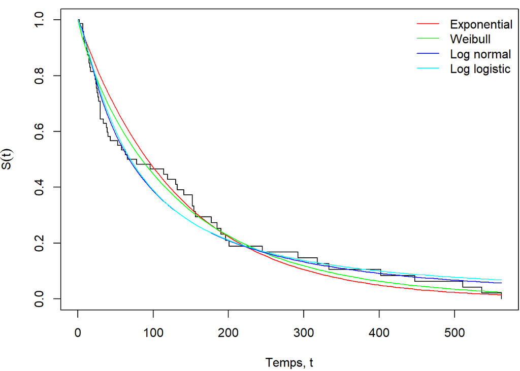

```r
par(mar = c(4, 4, .5, 0) + .1)
plot(survfit(Surv(time, status) ~ 1, data = kidney), conf.int = FALSE, xlab = 'Temps, t',ylab = bquote(paste(S(t))), col = "black")
curve(exp(-lambda_exp*x),add=T,col='red')
curve(exp(-(x/lambda_weib)^(1/scale_weib)),add=T,col="green")
curve(1-pnorm((log(x)-mu_logNorm)/scale_logNorm),add=T,col="blue")
curve(1/(1+exp((log(x)-mu_logLogi)/scale_logLogi)),add=T,col="cyan")
legend("topright",c("Exponential","Weibull","Log normal","Log logistic"),col=c("red","green","blue","cyan"),lty=1,bty="n")
```

#### 3.2.5.2 Ajustement sur le sexe

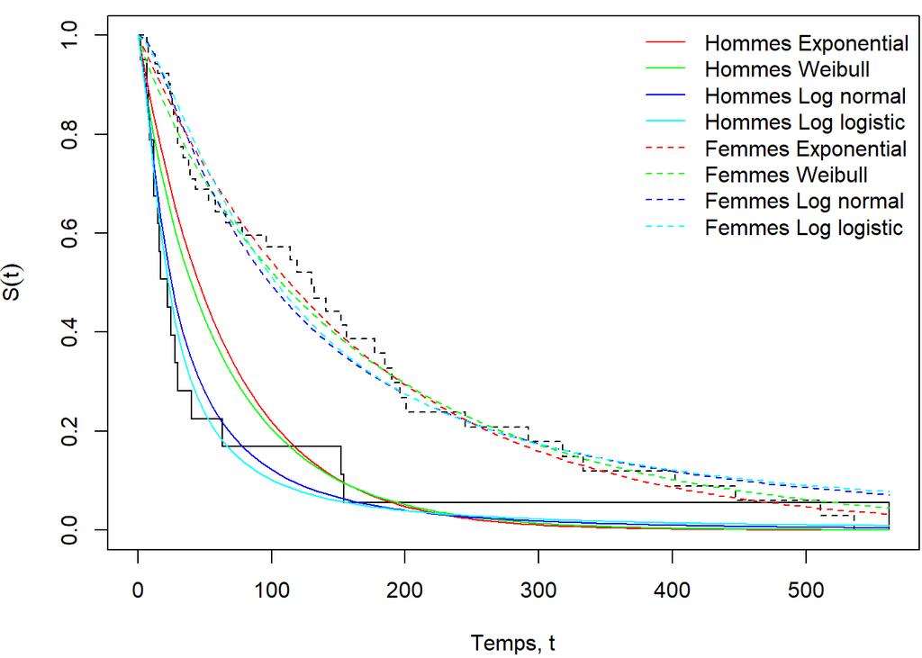

```r
par(mar = c(4, 4, .5, 0) + .1)
plot(survfit(Surv(time, status) ~ sex, data = kidney), conf.int = FALSE, xlab = 'Temps, t',ylab = bquote(paste(S(t))), col = "black", lty = c(1,2))

curve(exp(-exp(-betas_exp[1])*x),add=T,col='red')
curve(exp(-exp(-sum(betas_exp))*x),add=T,col='red', lty=2)

curve(exp(-(x/exp(+betas_weib[1]))^(1/scale_weib2)),add=T,col="green")
curve(exp(-(x/exp(sum(betas_weib)))^(1/scale_weib2)),add=T,col="green", lty=2)

curve(1-pnorm((log(x)-mu_logNorm2[1])/scale_logNorm2),add=T,col="blue")
curve(1-pnorm((log(x)-sum(mu_logNorm2))/scale_logNorm2),add=T,col="blue", lty=2)

curve(1/(1+exp((log(x)-mu_logLogi2[1])/scale_logLogi2)),add=T,col="cyan")
curve(1/(1+exp((log(x)-sum(mu_logLogi2))/scale_logLogi2)),add=T,col="cyan", lty=2)

legend("topright",c(paste("Hommes",c("Exponential","Weibull","Log normal","Log logistic")),
                    paste("Femmes",c("Exponential","Weibull","Log normal","Log logistic")  )), col=rep(c("red","green","blue","cyan"),2), lty=c(rep(1,4),rep(2,4)),bty="n")
```

## 3.3 Médiane de survie (Utilisation de l’estimation avec l’intercept uniquement)

L’avantage d’avoir une distribution paramétrique et que nous avons des solutions analytiques qui nous permettent d’obtenir des statistiques facilement à partir de quelques formules bien connues (moyenne,…). La médiane de survie s’obtient facilement à partir de la fonction de répartition. Sous R, les fonctions des distribution usuelles peuvent être utilisée :

```r
qexp(0.5,lambda_exp)
```

```
## [1] 92.30808
```

```r
qweibull(0.5,1/scale_weib,lambda_weib)
```

```
## [1] 84.75924
```

```r
qlnorm(0.5,mu_logNorm,scale_logNorm)
```

```
## [1] 68.30858
```

(Pour la log-logistique, d’autres packages sont nécessaires, ex : `flexsurv`)

On peut vérifier sur le plot :

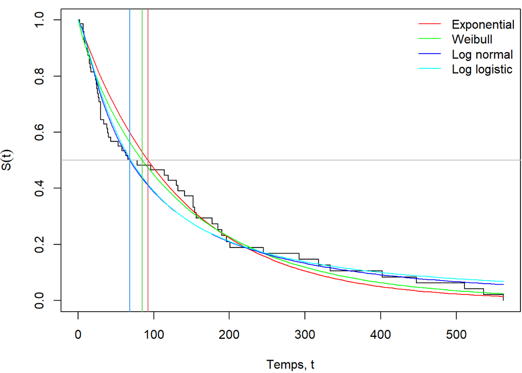

```r
par(mar = c(4, 4, .5, 0) + .1)
plot(survfit(Surv(time, status) ~ 1, data = kidney), conf.int = FALSE, xlab = 'Temps, t',ylab = bquote(paste(S(t))), col = "black")
curve(exp(-lambda_exp*x),add=T,col='red')
curve(exp(-(x/lambda_weib)^(1/scale_weib)),add=T,col="green")
curve(1-pnorm((log(x)-mu_logNorm)/scale_logNorm),add=T,col="blue")
curve(1/(1+exp((log(x)-mu_logLogi)/scale_logLogi)),add=T,col="cyan")
legend("topright",c("Exponential","Weibull","Log normal","Log logistic"),col=c("red","green","blue","cyan"),lty=1,bty="n")
abline(h=0.5,col="gray")
abline(v=c(qexp(0.5,lambda_exp),qweibull(0.5,1/scale_weib,lambda_weib),qlnorm(0.5,mu_logNorm,scale_logNorm)),col=2:4)
```

## 3.4 Extrapolation

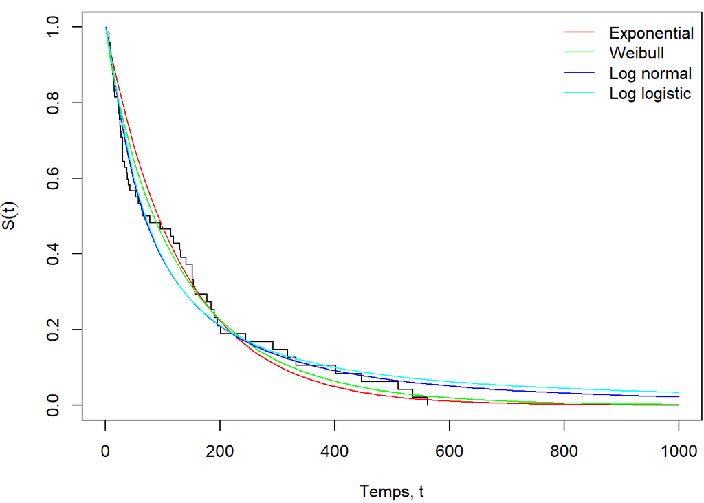

```r
par(mar = c(4, 4, .5, 0) + .1)
plot(survfit(Surv(time, status) ~ 1, data = kidney),xlim=c(0,1000), conf.int = FALSE, xlab = 'Temps, t',ylab = bquote(paste(S(t))), col = "black")
curve(exp(-lambda_exp*x),add=T,col='red')
curve(exp(-(x/lambda_weib)^(1/scale_weib)),add=T,col="green")
curve(1-pnorm((log(x)-mu_logNorm)/scale_logNorm),add=T,col="blue")
curve(1/(1+exp((log(x)-mu_logLogi)/scale_logLogi)),add=T,col="cyan")
legend("topright",c("Exponential","Weibull","Log normal","Log logistic"),col=c("red","green","blue","cyan"),lty=1,bty="n")
```

## 3.5 Prédiction

Réalisons des prédictions pour nos observations :

```r
predict(fit_weib)
```

```
##  [1] 128.0324 128.0324 128.0324 128.0324 128.0324 128.0324 128.0324 128.0324
##  [9] 128.0324 128.0324 128.0324 128.0324 128.0324 128.0324 128.0324 128.0324
## [17] 128.0324 128.0324 128.0324 128.0324 128.0324 128.0324 128.0324 128.0324
## [25] 128.0324 128.0324 128.0324 128.0324 128.0324 128.0324 128.0324 128.0324
## [33] 128.0324 128.0324 128.0324 128.0324 128.0324 128.0324 128.0324 128.0324
## [41] 128.0324 128.0324 128.0324 128.0324 128.0324 128.0324 128.0324 128.0324
## [49] 128.0324 128.0324 128.0324 128.0324 128.0324 128.0324 128.0324 128.0324
## [57] 128.0324 128.0324 128.0324 128.0324 128.0324 128.0324 128.0324 128.0324
## [65] 128.0324 128.0324 128.0324 128.0324 128.0324 128.0324 128.0324 128.0324
## [73] 128.0324 128.0324 128.0324 128.0324
```

On peut constater que la moyenne de la distribution de Weibull est assigné à toutes les observations. Ces valeurs seront modifiées en fonction des facteurs d’ajustement pris en compte dans le modèle. Ex :

```r
fit_weib2<-survreg(Surv(time,status) ~ sex, kidney,dist="weibull")
#summary(fit_weib2)
#prediction pour sex = 1
print(paste0("Prédiction pour les hommes : ",predict(fit_weib2,newdata = list(sex=0))))
```

```
## [1] "Prédiction pour les hommes : 60.0207658516785"
```

```r
#prediction pour sex = 2
print(paste0("Prédiction pour les femmes : ",predict(fit_weib2,newdata = list(sex=1))))
```

```
## [1] "Prédiction pour les femmes : 160.982192998575"
```

Mais quand on regarde le graphique, il y a peut être un meilleur modèle :

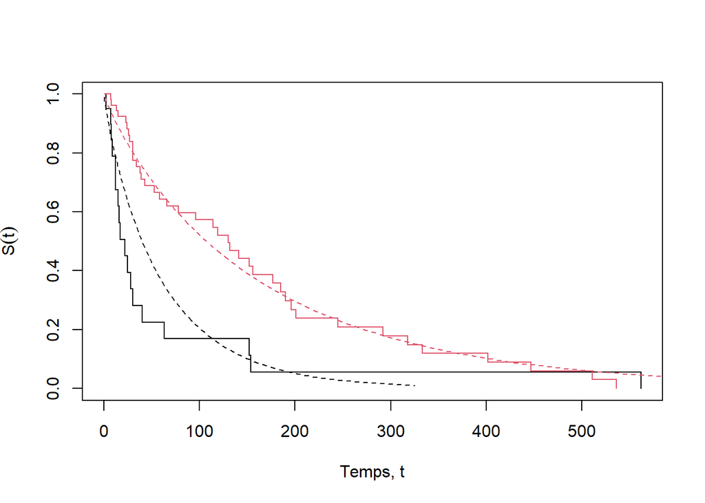

```r
plot(survfit(Surv(time, status) ~ sex, data = kidney), conf.int = FALSE, xlab = 'Temps, t',ylab = bquote(paste(S(t))), col=1:2)
p<-seq(0.01, 0.99, by=.01)
lines(x = predict(fit_weib2, type = "quantile", p = p, newdata=list(sex=0)), y = rev(p),lty=2)
lines(x = predict(fit_weib2, type = "quantile", p = p, newdata=list(sex=1)), y = rev(p),col=2,lty=2)
```

## 3.6 Comparaison des modèles

### 3.6.1 Comparaison “intra-distribution”

Le dataset n’ayant pas beaucoup d’observations, le test de rapport de vraisemblance est à privilégier.

```r
anova(fit_weib,fit_weib2)
```

```
##   Terms Resid. Df    -2*LL Test Df Deviance    Pr(>Chi)
## 1     1        74 681.8749      NA       NA          NA
## 2   sex        73 673.2625    =  1 8.612403 0.003338815
```

Nous pouvons également regarder les critères AIC et BIC (plus faible est meilleur) :

```r
#AIC
extractAIC(fit_weib)
```

```
## [1]   2.0000 685.8749
```

```r
extractAIC(fit_weib2)
```

```
## [1]   3.0000 679.2625
```

```r
#BIC
extractAIC(fit_weib,k=log(nrow(kidney)))
```

```
## [1]   2.0000 690.5363
```

```r
extractAIC(fit_weib2,k=log(nrow(kidney)))
```

```
## [1]   3.0000 686.2547
```

Tous les critères indiquent que l’ajustement sur la variable sex permettent d’améliorer les performances du modèle.

### 3.6.2 Comparaison “inter-distribution”

#### 3.6.2.1 Comparaison modèles emboités

Le modèle exponentiel correspond au modèle de Weibull pour $\sigma=1$. Ces 2 modèles sont donc emboités et nous pouvons réaliser le test de rapport de vraisemblance.

```r
anova(fit_exp,fit_weib)
```

```
##   Terms Resid. Df    -2*LL Test Df Deviance  Pr(>Chi)
## 1     1        75 683.4308      NA       NA        NA
## 2     1        74 681.8749    =  1 1.555899 0.2122668
```

Regardons également les autres critères :

```r
#AIC
extractAIC(fit_exp)
```

```
## [1]   1.0000 685.4308
```

```r
extractAIC(fit_weib)
```

```
## [1]   2.0000 685.8749
```

```r
#BIC
extractAIC(fit_exp,k=log(nrow(kidney)))
```

```
## [1]   1.0000 687.7615
```

```r
extractAIC(fit_weib,k=log(nrow(kidney)))
```

```
## [1]   2.0000 690.5363
```

Dans tous les cas, les critères indique que le modèle de Weibull n’est pas meilleur que le modèle exponentiel. Le modèle exponentiel, plus simple, sera donc à privilégier.

#### 3.6.2.2 Comparaison modèles non-emboités

Le rapport de vraisemblance n’est plus valable dans ce cas. Utilisons donc les autres critères :

```r
k=log(nrow(kidney))
data.frame(model=c("Exponentiel","Weibull","log-normal","log-logistique"),
           AIC=c(extractAIC(fit_exp)[2],extractAIC(fit_weib)[2],extractAIC(fit_logNorm)[2],extractAIC(fit_logLogi)[2]),
           BIC=c(extractAIC(fit_exp,k=k)[2],extractAIC(fit_weib,k=k)[2],extractAIC(fit_logNorm,k=k)[2],extractAIC(fit_logLogi,k=k)[2]))
```

```
##            model      AIC      BIC
## 1    Exponentiel 685.4308 687.7615
## 2        Weibull 685.8749 690.5363
## 3     log-normal 684.0963 688.7578
## 4 log-logistique 688.0928 692.7543
```

Le modèle log-normal a le meilleur AIC, alors que le modèle exponentiel a le meilleur BIC. Cependant, les différences sont très faibles. Comme précédemment, le modèle le plus simplte (exponentiel) sera donc à favoriser.

Cependant, en prennant en compte un ajustement sur la variable sex, le modèle log-normal sera à privilégier.

```r
fit_exp2<-survreg(Surv(time,status) ~ sex, kidney,dist="exponential")
fit_logNorm2<-survreg(Surv(time,status) ~ sex, kidney,dist="lognormal")
fit_logLogi2<-survreg(Surv(time,status) ~ sex, kidney,dist="loglogistic")
k=log(nrow(kidney))
data.frame(model=c("Exponentiel","Weibull","log-normal","log-logistique"),
           AIC=c(extractAIC(fit_exp2)[2],extractAIC(fit_weib2)[2],extractAIC(fit_logNorm2)[2],extractAIC(fit_logLogi2)[2]),
           BIC=c(extractAIC(fit_exp2,k=k)[2],extractAIC(fit_weib2,k=k)[2],extractAIC(fit_logNorm2,k=k)[2],extractAIC(fit_logLogi2,k=k)[2]))
```

```
##            model      AIC      BIC
## 1    Exponentiel 678.4875 683.1490
## 2        Weibull 679.2625 686.2547
## 3     log-normal 670.2552 677.2474
## 4 log-logistique 672.0271 679.0193
```